# SOC-GA 2332 Intro to Stats Lab 12

Di Zhou

5/7/2021

## Part 1: Using Weights in Descriptive Statistics and Regression for IPUMS data

We will use the IPUMS PERWT (person weight) variable to demonstrate how to use weights for descriptive statistics and regression models.

First, it is useful to review the PERWT variable description:

> PERWT indicates how many persons in the U.S. population are represented by a given person in an IPUMS sample.  
> It is generally a good idea to use PERWT when conducting a person-level analysis of any IPUMS sample. The use of PERWT is optional when analyzing one of the “flat” or unweighted IPUMS samples. Flat IPUMS samples include the 1% samples from 1850-1930, all samples from 1960, 1970, and 1980, the 1% unweighted samples from 1990 and 2000, the 10% 2010 sample, and any of the full count 100% census datasets. PERWT must be used to obtain nationally representative statistics for person-level analyses of any sample other than those.

In R, the `TAM` package can be used to generate weighted descriptive statistics. For regression models, you can directly input the weights in the `lm()` function.

```r
# -------Load data-------
wt_example <- read.csv("data/wt_example.csv")

# -------Descriptive statistics-------

# -------1. Numeric variables-------
# unweighted mean, var, and sd
mean <- mean(wt_example$INCWAGE)
var <- var(wt_example$INCWAGE)
sd <- sd(wt_example$INCWAGE)

# weighted mean, var, and sd
wt_mean <- weighted.mean(wt_example$INCWAGE, wt_example$PERWT)
wt_var <- weighted_var(wt_example$INCWAGE, wt_example$PERWT)
wt_sd <- weighted_sd(wt_example$INCWAGE, wt_example$PERWT)

# Compare
tibble(Statistics = c("Mean", "Var", "SD"),
       Unweighted = c(mean, var, sd),
       Weighted = c(wt_mean, wt_var, wt_sd)) %>%
  kbl("html") %>%
  kable_classic_2(full_width = F)
```

| Statistics | Unweighted | Weighted |
| --- | --- | --- |
| Mean | 24631.82 | 24481.89 |
| Var | 1779809492.30 | 1736234516.69 |
| SD | 42187.79 | 41668.15 |

```r
# -------2. Categorical variables-------
# Unweighted frequency table
table(wt_example$SEX)
```

```
##
##    1    2
## 8407 8915
```

```r
# Weighted frequency table
weighted_table(wt_example$SEX, wt_example$PERWT)
```

```
##         1         2
## 120683608 122579576
```

```r
# -------Regression-------

# Since log(0) = -inf, you can add a very small number to INCWAGE before log transformation
# but this assumes that those have 0 wage are homogenous populations,
# whereas in reality it can be a TRUNCATED data (see Lecture 12 Slide 38 to 40)

# Unweigthed regression
m1 <- lm(log(INCWAGE + 0.01) ~ SEX + EDUC + SEX*EDUC, data = wt_example)
# Weigthed regression
m2 <- lm(log(INCWAGE + 0.01) ~ SEX + EDUC + SEX*EDUC, data = wt_example, weights = PERWT)

# Compare results
stargazer(m1, m2,
          type = "text",
          column.labels = c("Unweighted", "Weighted"),
          dep.var.labels = "Log Wage")
```

```
##
## =============================================================
##                                      Dependent variable:
##                                  ----------------------------
##                                            Log Wage
##                                    Unweighted     Weighted
##                                       (1)            (2)
## -------------------------------------------------------------
## SEX                                -2.639***      -2.680***
##                                     (0.341)        (0.334)
##
## EDUC                                0.505***      0.493***
##                                     (0.073)        (0.071)
##
## SEX:EDUC                            0.211***      0.220***
##                                     (0.046)        (0.045)
##
## Constant                            2.347***      2.675***
##                                     (0.539)        (0.526)
##
## -------------------------------------------------------------
## Observations                         17,322        17,322
## R2                                   0.075          0.077
## Adjusted R2                          0.075          0.077
## Residual Std. Error (df = 17318)     6.957         814.846
## F Statistic (df = 3; 17318)        471.312***    483.754***
## =============================================================
## Note:                             *p<0.1; **p<0.05; ***p<0.01
```

## Part 2: Matching

For following parts on causal inference, we will use the Early Childhood Longitudinal Study dataset. We will examine the effect of going to a Catholic school (`catholic = 1`), as opposed to a public school (`catholic = 0`), on students’ standardized math score (`c5r2mtsc_std`). The pre-treatment covariates are:  
* `race_white`: Is the student white (1) or not (0)?  
* `p5hmage`: Mother’s age  
* `w3income`: Family income  
* `p5numpla`: Number of places the student has lived for at least 4 months  
* `w3momed_hsb`: Is the mother’s education level high-school or below (1) or some college or more (0)?

```r
#import data
ecls <- read.csv("data/ecls.csv") # the Early Childhood Longitudinal Study

# covariates variable name vector
ecls_cov <- c('race_white', 'p5hmage', 'w3income', 'p5numpla', 'w3momed_hsb')
```

### Check if sample is balanced

To check if the sample is balanced or not, we first examine the difference in means by treatment status for outcome variable and covariates As we can see, the difference in mean for match score and for covariates are statistically significant.

```r
# Check difference in means by school type
ecls %>%
  group_by(catholic) %>%
  summarise(n_students = n(),
            mean_math = mean(c5r2mtsc_std),
            std_error_math = sd(c5r2mtsc_std) / sqrt(n_students)) %>%
  kbl("html") %>%
  kable_classic_2(full_width = F)
```

| catholic | n_students | mean_math | std_error_math |
| --- | --- | --- | --- |
| 0 | 9568 | -0.0305958 | 0.0103854 |
| 1 | 1510 | 0.1938682 | 0.0223528 |

```r
# Two Sample t-test: (H0: mean math scores do not differ by school types)
with(ecls, t.test(c5r2mtsc_std ~ catholic))
```

```
##
##  Welch Two Sample t-test
##
## data:  c5r2mtsc_std by catholic
## t = -9.1069, df = 2214.5, p-value < 0.00000000000000022
## alternative hypothesis: true difference in means is not equal to 0
## 95 percent confidence interval:
##  -0.2727988 -0.1761292
## sample estimates:
## mean in group 0 mean in group 1
##     -0.03059583      0.19386817
```

```r
# Check difference in means for pre-treatment covariates by school types

# summarise group means for covariates
ecls %>%
  group_by(catholic) %>%
  select(one_of(ecls_cov)) %>%
  summarise_all(funs(mean(., na.rm = T))) %>%
  kbl("html") %>%
  kable_classic_2(full_width = F)
```

| catholic | race_white | p5hmage | w3income | p5numpla | w3momed_hsb |
| --- | --- | --- | --- | --- | --- |
| 0 | 0.5561246 | 37.56097 | 54889.16 | 1.132669 | 0.4640918 |
| 1 | 0.7251656 | 39.57516 | 82074.30 | 1.092701 | 0.2272069 |

```r
# Two sample t-test for every covariate
# lapply: a build-in loop that apply the t-test function along the name vector
lapply(ecls_cov, function(v) {
  t.test(ecls[, v] ~ ecls[, 'catholic'])
})
```

```
## [[1]]
##
##  Welch Two Sample t-test
##
## data:  ecls[, v] by ecls[, "catholic"]
## t = -13.453, df = 2143.3, p-value < 0.00000000000000022
## alternative hypothesis: true difference in means is not equal to 0
## 95 percent confidence interval:
##  -0.1936817 -0.1444003
## sample estimates:
## mean in group 0 mean in group 1
##       0.5561246       0.7251656
##
##
## [[2]]
##
##  Welch Two Sample t-test
##
## data:  ecls[, v] by ecls[, "catholic"]
## t = -12.665, df = 2186.9, p-value < 0.00000000000000022
## alternative hypothesis: true difference in means is not equal to 0
## 95 percent confidence interval:
##  -2.326071 -1.702317
## sample estimates:
## mean in group 0 mean in group 1
##        37.56097        39.57516
##
##
## [[3]]
##
##  Welch Two Sample t-test
##
## data:  ecls[, v] by ecls[, "catholic"]
## t = -20.25, df = 1825.1, p-value < 0.00000000000000022
## alternative hypothesis: true difference in means is not equal to 0
## 95 percent confidence interval:
##  -29818.10 -24552.18
## sample estimates:
## mean in group 0 mean in group 1
##        54889.16        82074.30
```

[output cut: 13 more lines]

```
##        1.132669        1.092701
##
##
## [[5]]
##
##  Welch Two Sample t-test
##
## data:  ecls[, v] by ecls[, "catholic"]
## t = 18.855, df = 2107.3, p-value < 0.00000000000000022
## alternative hypothesis: true difference in means is not equal to 0
## 95 percent confidence interval:
##  0.2122471 0.2615226
## sample estimates:
## mean in group 0 mean in group 1
##       0.4640918       0.2272069
```

### Choose and execute a matching algorithm

To create a balanced sample from the original, unbalanced dataset, we need to choose and execute a matching algorithm in order to created a balanced dataset for estimate ATE. The package `MatchIt` estimates the propensity score in the background and then matches observations based on the method of your choice.

```r
# MatchIt does not allow missing values,
# so we need to remove observations with NAs
ecls_nomiss <- ecls %>%
  select(c5r2mtsc_std, catholic, all_of(ecls_cov)) %>%
  na.omit()

# Nearest neighbor matching (see documentation for different matching methods)
mod_match <- matchit(catholic ~ race_white + w3income + p5hmage + p5numpla + w3momed_hsb,
                     method = "nearest", data = ecls_nomiss)
```

### Create matched dataset

Using the `matchit` function, we obtained a `matchit` object (`mod_match`) that can be used to create a dataframe that contains only the matched observations.

Note that in our case, this final dataset is smaller than the original: it contains 2,704 observations, meaning that 1,352 pairs of treated and control observations were matched.

Also note that the final dataset contains a variable called `distance`, which is the propensity score.

```r
# To create a dataframe containing only the matched observations
dta_m <- match.data(mod_match)
```

### Examine covariates after matching

After matching, it is useful to plot the mean of each covariate against the estimated propensity score, color-coded by treatment status. If matching is done well, the treatment and control groups will have (near) identical means of each covariate at each value of the propensity score.

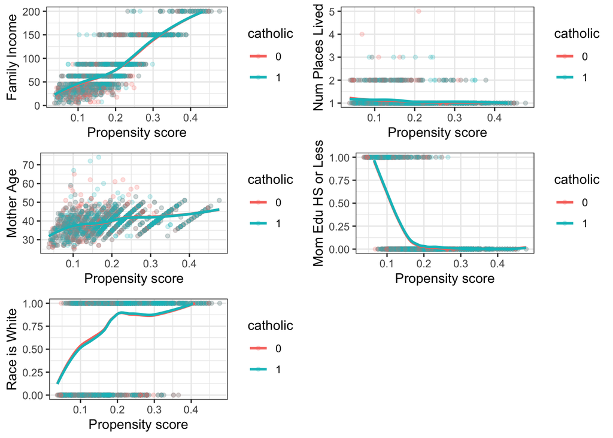

```r
# A plotting function that plots the distribution of propensity score of a given covariate
fn_bal <- function(dta, variable, yname) {
  dta$variable <- dta[, variable]
  if (variable == 'w3income') dta$variable <- dta$variable / 10^3
  dta$catholic <- as.factor(dta$catholic)
  support <- c(min(dta$variable), max(dta$variable))
  ggplot(dta, aes(x = distance, y = variable, color = catholic)) +
    geom_point(alpha = 0.2, size = 1.3) +
    geom_smooth(method = "loess", se = F) +
    xlab("Propensity score") +
    ylab(yname) +
    theme_bw() +
    ylim(support)
}

# Plot and arrange the plots
grid.arrange(
  fn_bal(dta_m, "w3income", "Family Income"),
  fn_bal(dta_m, "p5numpla", "Num Places Lived"),
  fn_bal(dta_m, "p5hmage", "Mother Age"),
  fn_bal(dta_m, "w3momed_hsb", "Mom Edu HS or Less"),
  fn_bal(dta_m, "race_white", "Race is White"),
  nrow = 3)
```

```r
# You can also check difference-in-means in matched data
dta_m %>%
  group_by(catholic) %>%
  select(one_of(ecls_cov)) %>%
  summarise_all(funs(mean)) %>%
  kbl("html") %>%
  kable_classic_2(full_width = F)
```

| catholic | race_white | p5hmage | w3income | p5numpla | w3momed_hsb |
| --- | --- | --- | --- | --- | --- |
| 0 | 0.7470414 | 39.5503 | 81403.99 | 1.076183 | 0.2152367 |
| 1 | 0.7411243 | 39.5932 | 82568.94 | 1.091716 | 0.2233728 |

```r
# two sample t-test
lapply(ecls_cov, function(v) {
  t.test(dta_m[, v] ~ dta_m$catholic)
})
```

```
## [[1]]
##
##  Welch Two Sample t-test
##
## data:  dta_m[, v] by dta_m$catholic
## t = 0.35243, df = 2701.8, p-value = 0.7245
## alternative hypothesis: true difference in means is not equal to 0
## 95 percent confidence interval:
##  -0.02700440  0.03883872
## sample estimates:
## mean in group 0 mean in group 1
##       0.7470414       0.7411243
##
##
## [[2]]
##
##  Welch Two Sample t-test
##
## data:  dta_m[, v] by dta_m$catholic
## t = -0.21331, df = 2702, p-value = 0.8311
## alternative hypothesis: true difference in means is not equal to 0
## 95 percent confidence interval:
##  -0.4372485  0.3514496
## sample estimates:
## mean in group 0 mean in group 1
##         39.5503         39.5932
##
##
## [[3]]
##
##  Welch Two Sample t-test
##
## data:  dta_m[, v] by dta_m$catholic
## t = -0.64787, df = 2701.9, p-value = 0.5171
## alternative hypothesis: true difference in means is not equal to 0
## 95 percent confidence interval:
##  -4690.731  2360.845
## sample estimates:
## mean in group 0 mean in group 1
##        81403.99        82568.94
```

[output cut: 13 more lines]

```
##        1.076183        1.091716
##
##
## [[5]]
##
##  Welch Two Sample t-test
##
## data:  dta_m[, v] by dta_m$catholic
## t = -0.51108, df = 2701.5, p-value = 0.6093
## alternative hypothesis: true difference in means is not equal to 0
## 95 percent confidence interval:
##  -0.03935185  0.02307966
## sample estimates:
## mean in group 0 mean in group 1
##       0.2152367       0.2233728
```

### Estimate Average Treatment Effects

Using matched dataset, we can now estimate ATE using two different methods. We can either use the results of a two sample t-test and calculate the difference in means, or regress mean math score on school types. Note that since we are using the matched dataset, the distribution of the covariates are balanced in both the treatment and control group, and therefore with our without control variables in the linear model would not affect the ATE estimate.

```r
# 1. Two sample t-test
with(dta_m, t.test(c5r2mtsc_std ~ catholic))
```

```
##
##  Welch Two Sample t-test
##
## data:  c5r2mtsc_std by catholic
## t = 4.2645, df = 2676.3, p-value = 0.00002073
## alternative hypothesis: true difference in means is not equal to 0
## 95 percent confidence interval:
##  0.08086619 0.21853174
## sample estimates:
## mean in group 0 mean in group 1
##       0.3593668       0.2096679
```

```r
# mean in group 0: 0.3593668
# mean in group 1: 0.2096679
# ATE = 0.2096679 - 0.3593668 = -0.1496989

# 2. OLS model
# no covariates
lm_treat1 <- lm(c5r2mtsc_std ~ catholic, data = dta_m)
# with covariates
lm_treat2 <- lm(c5r2mtsc_std ~ catholic + race_white + p5hmage +
                  I(w3income / 10^3) + p5numpla + w3momed_hsb, data = dta_m)
# display models
stargazer(lm_treat1, lm_treat2, type="text",
          omit.table.layout = "sn", star.char = c("+", "*", "**", "***"),
          star.cutoffs = c(0.1, 0.05, 0.01, 0.001))
```

```
##
## ====================================
##                 Dependent variable:
##                 --------------------
##                     c5r2mtsc_std
##                    (1)        (2)
## ------------------------------------
## catholic        -0.150***  -0.149***
##                  (0.035)    (0.033)
##
## race_white                 0.310***
##                             (0.039)
##
## p5hmage                    0.012***
##                             (0.003)
##
## I(w3income/103)            0.003***
##                            (0.0004)
##
## p5numpla                    -0.041
##                             (0.055)
##
## w3momed_hsb                -0.358***
##                             (0.041)
##
## Constant         0.359***  -0.482**
##                  (0.025)    (0.148)
##
## ====================================
## ====================================
```

## Part 3: Propensity Score

This part will demonstrate how to create propensity score. Recall that propensity score is the probability of being treated given a set of pre-treatment covariates. In R, we can estimate propensity score given the covariates by fitting a logistic regression with the treatment status as the outcome and covariates as predictors.

Note that there is a limitation for this method of estimation, because we do not consider unmeasured and unobserved covariates.

```r
# Rescale income
ecls <- ecls %>% mutate(w3income_1k = w3income/1000) # mutate: add new variables

# Fit a logistic regress to generate propensity score using covariates
# Note we assume that there is no unobserved covariates, which can be a limitation
# Compared to OLS, the propsensity score relaxes some of the linear assumptions.
m_ps <- glm(catholic ~ race_white + w3income_1k + p5hmage + p5numpla + w3momed_hsb,
            family = binomial(), data = ecls)
summary(m_ps)
```

```
##
## Call:
## glm(formula = catholic ~ race_white + w3income_1k + p5hmage +
##     p5numpla + w3momed_hsb, family = binomial(), data = ecls)
##
## Deviance Residuals:
##     Min       1Q   Median       3Q      Max
## -1.1883  -0.6140  -0.4508  -0.3336   2.5659
##
## Coefficients:
##               Estimate Std. Error z value             Pr(>|z|)
## (Intercept) -3.2125519  0.2379826 -13.499 < 0.0000000000000002 ***
## race_white   0.3145014  0.0700895   4.487        0.00000721848 ***
## w3income_1k  0.0073038  0.0006495  11.245 < 0.0000000000000002 ***
## p5hmage      0.0292168  0.0050771   5.755        0.00000000869 ***
## p5numpla    -0.1439392  0.0912255  -1.578                0.115
## w3momed_hsb -0.6935868  0.0743207  -9.332 < 0.0000000000000002 ***
## ---
## Signif. codes:  0 '***' 0.001 '**' 0.01 '*' 0.05 '.' 0.1 ' ' 1
##
## (Dispersion parameter for binomial family taken to be 1)
##
##     Null deviance: 7701.3  on 9266  degrees of freedom
## Residual deviance: 7168.8  on 9261  degrees of freedom
##   (1811 observations deleted due to missingness)
## AIC: 7180.8
##
## Number of Fisher Scoring iterations: 5
```

```r
# Use above model to generate propensity
# (the probability of being treated given a set of pre-treatment covariates)
prs_df <- data.frame(pr_score = predict(m_ps, type = "response"),
                     catholic = m_ps$model$catholic)

head(prs_df) %>%
  kbl("html") %>%
  kable_classic_2(full_width = F)
```

|  | pr_score | catholic |
| --- | --- | --- |
| 1 | 0.2292928 | 0 |
| 2 | 0.1801360 | 0 |
| 4 | 0.2092957 | 0 |
| 5 | 0.2154022 | 1 |
| 6 | 0.3604931 | 0 |
| 7 | 0.1080608 | 0 |

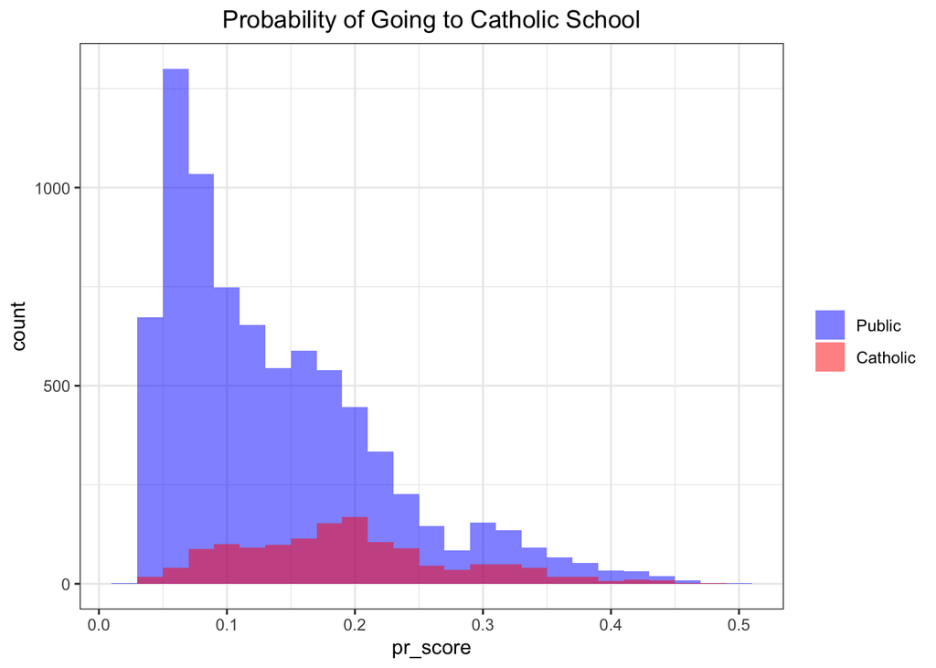

```r
# Check the region of common support
# In every unit in the treatment, is there a control unit?
prs_df %>%
  ggplot(aes(x = pr_score, fill = as.factor(catholic))) +
  geom_histogram(binwidth = 0.02, alpha = 0.5, position="identity") +
  ggtitle("Probability of Going to Catholic School") +
  theme_bw() +
  theme(plot.title = element_text(hjust = 0.5)) +
  scale_fill_manual(name=" ",
                    values = c("blue", "red"),
                    labels = c("Public", "Catholic"))
```

```r
# blue: control group: red: treatment group
```

## Part 4: Instrumental Variables

In this part I share three classic papers that used Instrumental Variables to estimate causal effects.

1. The effect of participating in war on long-term wage, using **lottery number as IV**:  
   [Lifetime Earnings and the Vietnam Era Draft Lottery: Evidence from Social Security Administrative Records](https://www.jstor.org/stable/2006669?seq=1#metadata_info_tab_contents), by Joshua D. Angrist, 1990, American Economic Review
2. The effect of religious reform on literacy (human capital), using **distance to the religous reform center as IV**:  
   [Was Weber Wrong? A Human Capital Theory of Protestant Economic History](https://academic.oup.com/qje/article/124/2/531/1905076), by Sascha O. Becker and Ludger Woessmann, 2009, Quarterly Journal of Economics
3. The effect of using plough on modern day gender value, using **soil type as IV**: [On the Origins of Gender Roles: Women and the Plough](https://academic.oup.com/qje/article/128/2/469/1943509), by Alberto Alesina, Paola Giuliano, Nathan Nunn, 2013, Quarterly Journal of Economics